# An Introduction to Text Analysis

DDD: Elements of Statistical Machine Learning & Politics of Data

Ayush Patel

At Azim Premji University

08 Mar, 2026

# Hello

I am Ayush.

I am a researcher working at the intersection of data, development and economics.

I am a [RStudio (Posit) certified tidyverse Instructor.](https://education.rstudio.com/trainers/people/patel+ayush/)

I am a Researcher at [Oxford Poverty and Human development Initiative (OPHI)](https://ophi.org.uk/), at the University of Oxford.

[figure not shown]

[Hello (Eh bonjour– donc–.) by Charles Motte](https://www.metmuseum.org/art/collection/search/392118%22Well)

# Did you come prepared?

- You have installed R. If not see this link.
- You have installed RStudio/Positron/VScode or any other IDE. It is recommended that you work through an IDE
- You have the libraries `{tidytext} {sentimentr} {quanteda} {magrittr} {topicmodels} {ldatuning} {keras} {recipes} {textrecipes}` installed

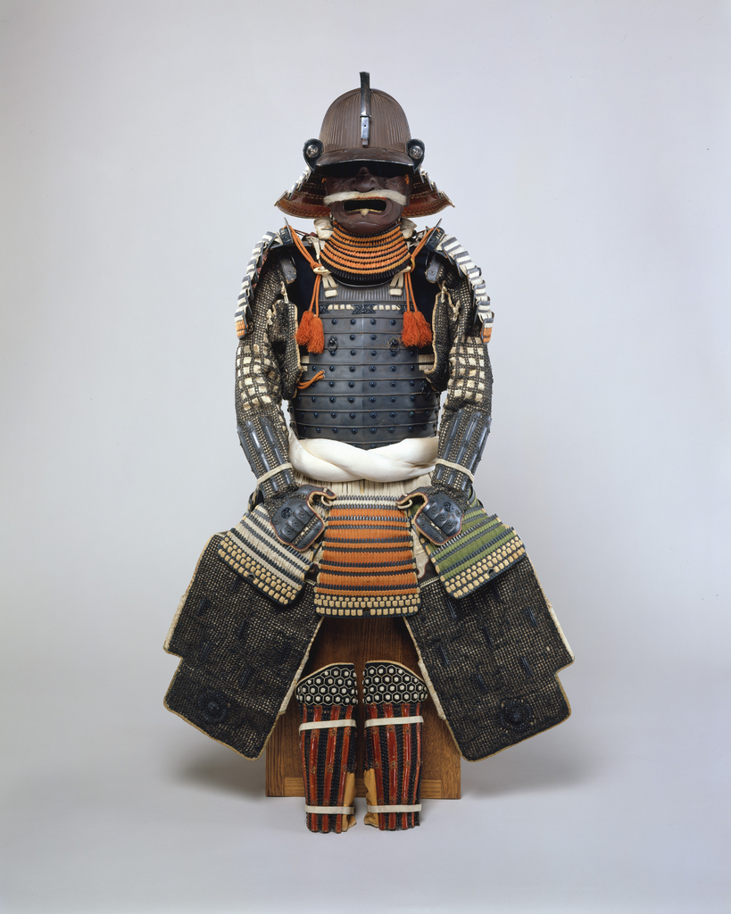

[Armor (Gusoku) Helmet signed by Bamen Tomotsugu](https://www.metmuseum.org/art/collection/search/24975)

# Before NLP and Text Analysis

One needs to know how to mine, warngle, and manipulate text data.  
tidy priciples can make this task easy (relatively)  
*“Treating text as data frames of individual words allows us to manipulate, summarize, and visualize the characteristics of text easily and integrate natural language processing into effective workflows…”*  
We do this using the {tidytext} along with other know methods

# Tidy Data

As described in [Wickham 2014](https://www.jstatsoft.org/article/view/v059i10)

1. Each variable is a column.
2. Each observation is a row.
3. Each type of observational unit is a table.

# Tidy Text

As described by [Silge and Robinson 2017](https://www.tidytextmining.com/)

1. **A table with one-token-per-row**
2. token: A meaningful unit of text. (word,sentence,etc)
3. There are other forms of text data structures: string, corpus, document-term matric. (more on this later)

# Tokens

> “*A token is a meaningful unit of text, most often a word, that we are interested in using for further analysis, and tokenization is the process of splitting text into tokens.*”

# Unnesting Tokens

We need to get the text in *one-token-per-row* to acheive the Tidy Text format. This can be dome by the `unnest_tokens()` function from {tidytext}

```r
text <- c("Because I could not stop for Death -",
          "He kindly stopped for me -",
          "The Carriage held but just Ourselves -",
          "and Immortality")

text
```

```
[1] "Because I could not stop for Death -"
[2] "He kindly stopped for me -"
[3] "The Carriage held but just Ourselves -"
[4] "and Immortality"
```

# Unnesting Tokens

Notice any punctuations?

```
# A tibble: 20 × 2
     row word
   <int> <chr>
 1     1 because
 2     1 i
 3     1 could
 4     1 not
 5     1 stop
 6     1 for
 7     1 death
 8     2 he
 9     2 kindly
10     2 stopped
11     2 for
12     2 me
13     3 the
14     3 carriage
15     3 held
16     3 but
17     3 just
18     3 ourselves
19     4 and
20     4 immortality
```

# Unnesting Tokens

Tokens can be sentences, characters, lines, paragraphs, or a regex pattern  
Not all words are useful. We can remove *stop words*

# The RBI MPC minutes

See a sample [here](https://website.rbi.org.in/documents/87730/39710918/PR1769MPCf562eb05339b404f8dc23d07725ef354.pdf)

| identifier | lines |
| --- | --- |
| Minutes of the Monetary Policy Committee Meeting, February 4 to 6, 2026 | 2. The meeting was chaired by Shri Sanjay Malhotra, Governor and was attended |
| Minutes of the Monetary Policy Committee Meeting, February 4 to 6, 2026 | by all the members – Dr. Nagesh Kumar, Director and Chief Executive, Institute for |
| Minutes of the Monetary Policy Committee Meeting, February 4 to 6, 2026 | Studies in Industrial Development, New Delhi; Shri Saugata Bhattacharya, Economist, |
| Minutes of the Monetary Policy Committee Meeting, February 4 to 6, 2026 | Mumbai; Professor Ram Singh, Director, Delhi School of Economics, Delhi; Dr. |
| Minutes of the Monetary Policy Committee Meeting, February 4 to 6, 2026 | Poonam Gupta, Deputy Governor in charge of monetary policy and Shri Indranil |
| Minutes of the Monetary Policy Committee Meeting, February 4 to 6, 2026 | Bhattacharyya, Executive Director (the officer of the Reserve Bank nominated by the |
| Minutes of the Monetary Policy Committee Meeting, February 4 to 6, 2026 | Central Board under Section 45ZB(2)(c) of the Reserve Bank of India Act, 1934). |
| Minutes of the Monetary Policy Committee Meeting, February 4 to 6, 2026 | 3. According to Section 45ZL of the Reserve Bank of India Act, 1934, the Reserve |
| Minutes of the Monetary Policy Committee Meeting, February 4 to 6, 2026 | Bank shall publish, on the fourteenth day after every meeting of the Monetary Policy |
| Minutes of the Monetary Policy Committee Meeting, February 4 to 6, 2026 | Committee, the minutes of the proceedings of the meeting which shall include the |
| Minutes of the Monetary Policy Committee Meeting, February 4 to 6, 2026 | following, namely: |
| Minutes of the Monetary Policy Committee Meeting, February 4 to 6, 2026 | (a) the resolution adopted at the meeting of the Monetary Policy Committee; |
| Minutes of the Monetary Policy Committee Meeting, February 4 to 6, 2026 | (b) the vote of each member of the Monetary Policy Committee, ascribed to such |
| Minutes of the Monetary Policy Committee Meeting, February 4 to 6, 2026 | member, on the resolution adopted in the said meeting; and |
| Minutes of the Monetary Policy Committee Meeting, February 4 to 6, 2026 | (c) the statement of each member of the Monetary Policy Committee under sub- |
| Minutes of the Monetary Policy Committee Meeting, February 4 to 6, 2026 | section (11) of section 45ZI on the resolution adopted in the said meeting. |
| Minutes of the Monetary Policy Committee Meeting, February 4 to 6, 2026 | 4. The MPC reviewed in detail the staff’s macroeconomic projections, and |
| Minutes of the Monetary Policy Committee Meeting, February 4 to 6, 2026 | alternative scenarios around various risks to the outlook. The MPC also reviewed the |
| Minutes of the Monetary Policy Committee Meeting, February 4 to 6, 2026 | surveys conducted by the Reserve Bank to gauge consumer confidence, households’ |
| Minutes of the Monetary Policy Committee Meeting, February 4 to 6, 2026 | inflation expectations, corporate sector performance, credit conditions, the outlook for |
| Minutes of the Monetary Policy Committee Meeting, February 4 to 6, 2026 | the industrial, services and infrastructure sectors, and the projections of professional |
| Minutes of the Monetary Policy Committee Meeting, February 4 to 6, 2026 | forecasters. Drawing on the above and after extensive discussions on the stance of |
| Minutes of the Monetary Policy Committee Meeting, February 4 to 6, 2026 | monetary policy, the MPC adopted the resolution that is set out below. |
| Minutes of the Monetary Policy Committee Meeting, February 4 to 6, 2026 | Resolution |
| Minutes of the Monetary Policy Committee Meeting, February 4 to 6, 2026 | 5. The Monetary Policy Committee (MPC) held its 59th meeting from February 4 |
| Minutes of the Monetary Policy Committee Meeting, February 4 to 6, 2026 | to 6, 2026, under the chairmanship of Shri Sanjay Malhotra, Governor, Reserve Bank |
| Minutes of the Monetary Policy Committee Meeting, February 4 to 6, 2026 | of India. The MPC members Dr. Nagesh Kumar, Shri Saugata Bhattacharya, Prof. |
| Minutes of the Monetary Policy Committee Meeting, February 4 to 6, 2026 | Ram Singh, Dr. Poonam Gupta and Shri Indranil Bhattacharyya attended the meeting. |
| Minutes of the Monetary Policy Committee Meeting, February 4 to 6, 2026 | 6. After a detailed assessment of the evolving macroeconomic and financial |
| Minutes of the Monetary Policy Committee Meeting, February 4 to 6, 2026 | developments and the outlook, the MPC voted unanimously to keep the policy repo |

[output cut: 70 more lines]

# The RBI MPC minutes

**Unnest tokens to get tidytext format**

```r
mpc_minutes |>
  mutate(
    identifier = str_remove(identifier,".{1,}ting|.{1,}ting,")
  ) |>
  unnest_tokens(output = word,input = lines)  -> mpc_minutes_unnested

mpc_minutes_unnested
```

```
# A tibble: 417,226 × 2
   identifier              word
   <chr>                   <chr>
 1 , February 4 to 6, 2026 2
 2 , February 4 to 6, 2026 the
 3 , February 4 to 6, 2026 meeting
 4 , February 4 to 6, 2026 was
 5 , February 4 to 6, 2026 chaired
 6 , February 4 to 6, 2026 by
 7 , February 4 to 6, 2026 shri
 8 , February 4 to 6, 2026 sanjay
 9 , February 4 to 6, 2026 malhotra
10 , February 4 to 6, 2026 governor
# ℹ 417,216 more rows
```

# The RBI MPC minutes - removing stop words

**You can choose which stop words to remove**

```r
mpc_minutes_unnested |>
  anti_join(stop_words |>
  filter(!word %in% c("yes","no"))) -> mpc_minutes_unnested
```

# The RBI MPC Minutes - Word freq

**Notice any problems?**

```r
mpc_minutes_unnested |>
  count(word, sort = T)
```

```
# A tibble: 9,402 × 2
   word          n
   <chr>     <int>
 1 inflation  5757
 2 growth     3630
 3 cent       3363
 4 policy     3101
 5 rate       2340
 6 prices     1793
 7 monetary   1636
 8 food       1402
 9 demand     1327
10 global     1114
# ℹ 9,392 more rows
```

# The RBI MPC Minutes - Word freq

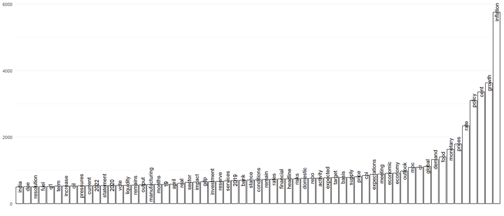

# Can do other stuff

**Is the MPC always attended by all the members**

```r
mpc_minutes |>
  group_by(identifier) |>
  summarise(
    attend_all = ifelse(sum(str_detect(lines,"was attended by all the members")) ==1,"Yes","No")
  ) |>
    ggplot(aes(x=""))+
    geom_bar(aes(fill = attend_all),
    position = "fill",
    width = 0.25)+
    scale_fill_manual(values = c("#b35a54ff","#6c8562ff"))+
    theme_minimal() +
    theme(
      legend.position = "none",
      plot.title.position = "plot",
      panel.grid.major.y = element_blank(),
      aspect.ratio = 0.25
    )+
    scale_y_continuous(expand = expansion(mult = c(0, 0)),limits = c(0,1))+
    scale_x_discrete(expand =  expansion(mult = c(0, 0)))+
    labs(
      x = NULL,
      y = NULL,
      title = "Proportion of MPC meetings that do not have all members present.",
      subtitle = "Green rpresents meetings with all members present. Red represents one or more absent members. n=58"
    ) +
    coord_flip()
```

# Can do other stuff

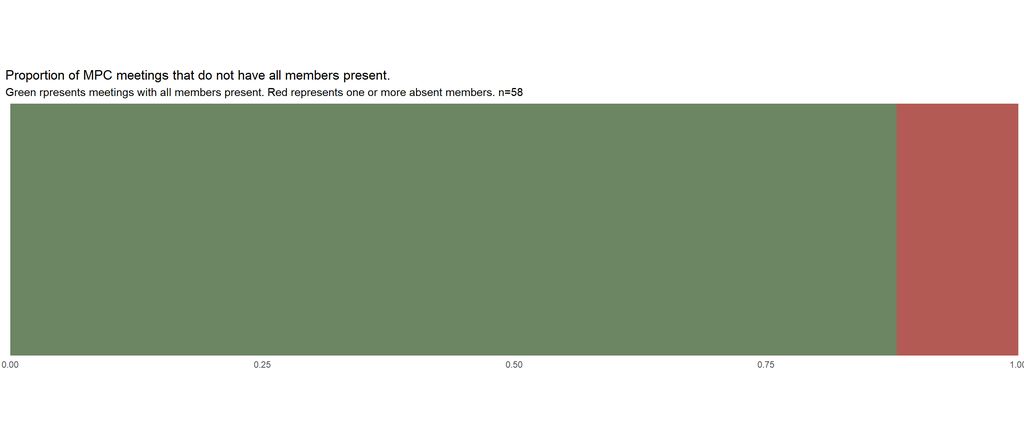

# Can do other stuff

**Is the decision making in the MPC usually unanimous?** [doc](https://website.rbi.org.in/documents/d/rbi/pr570202526_rbi) [doc1](https://website.rbi.org.in/documents/87730/39710918/PR1769MPCf562eb05339b404f8dc23d07725ef354.pdf)

```r
mpc_minutes |>
  filter(str_detect(lines, "[:alpha:]{1,}\\s{1,}Yes$") | str_detect(lines, "[:alpha:]{1,}\\s{1,}No$") |
  str_detect(lines, "[:alpha:]{1,}\\s{1,}Yes\\s{1,}[:digit:]{2}$") | str_detect(lines, "[:alpha:]{1,}\\s{1,}No\\s{1,}[:digit:]{2}$")) |>
  mutate(
    identifier = str_remove(identifier,"Minutes of the Monetary Policy Committee Meeting"),
    identifier = paste0(str_extract(identifier,"[:alpha:]{1,} "),str_extract(identifier," [:digit:]{4}")),
    individual = str_squish(str_extract(lines,"^.{1,}(?=Yes|No)")),
    identifier = lubridate::my(identifier),
    decision = str_squish(str_extract(lines," Yes| No| Yes | No "))
  ) |>
  select(-lines) |>
  ggplot(aes(identifier)) +
  geom_bar(aes(fill = decision)) +
  scale_fill_manual(values = c("#b35a54ff","#6c8562ff"))+
    labs(
      title = "MPC decisions across time.",
      x = NULL,
      y = "Number of Members",
      subtitle = "Green represents members in favour of resolution. Red represents members not in favour. n=58. 19/58 are not unanimous."
    ) +
    scale_y_continuous(expand = expansion(mult = c(0, 0)),limits = c(0,6))+
    scale_x_date(expand =  expansion(mult = c(0, 0)),
    breaks = scales::breaks_width("2 months"),
    labels = scales::label_date("%m-%y")
     )+
    theme_minimal() +
    theme(
      panel.grid.minor.x = element_blank(),
      axis.text.x = element_text(angle = 90),
      plot.title.position = "plot",
      legend.position = "none"
    )
```

# Can do other stuff

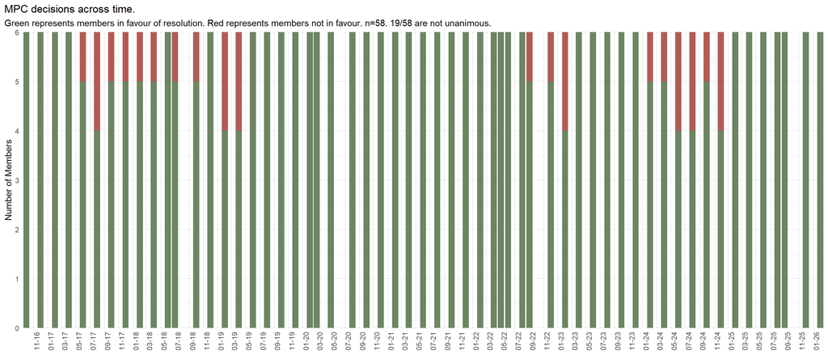

# Can AI do this

**Yes, be careful with what you want.**  
See [this](https://www.perplexity.ai/search/i-have-a-csv-file-containing-m-VzVGrVZ2T1uWsRO0bPoxNw)

# Can do other stuff

**who say no?**

```r
mpc_minutes |>
  filter(str_detect(lines, "[:alpha:]{1,}\\s{1,}Yes$") | str_detect(lines, "[:alpha:]{1,}\\s{1,}No$") |
  str_detect(lines, "[:alpha:]{1,}\\s{1,}Yes\\s{1,}[:digit:]{2}$") | str_detect(lines, "[:alpha:]{1,}\\s{1,}No\\s{1,}[:digit:]{2}$")) |>
  mutate(
    identifier = str_remove(identifier,"Minutes of the Monetary Policy Committee Meeting"),
    identifier = paste0(str_extract(identifier,"[:alpha:]{1,} "),str_extract(identifier," [:digit:]{4}")),
    individual = str_squish(str_extract(lines,"^.{1,}(?=Yes|No)")),
    identifier = lubridate::my(identifier),
    decision = str_squish(str_extract(lines," Yes| No| Yes | No "))
  ) |>
  select(-lines) |>
  mutate(
    individual = ifelse(str_detect(individual,"Dr.[:alpha:]"),
    str_replace(individual,pattern = "Dr.","Dr. "),
    individual)
    ) |>
  group_by(individual) |>
  summarise(
    n = n(),
    in_favour = sum(decision == "Yes"),
    not_in_favour = n - in_favour
  ) |>
    arrange(desc(n)) |>
    kableExtra::kable() |>
    kableExtra::kable_styling() |>
    kableExtra::scroll_box(width = '100%', height = '500px')
```

# Can do other stuff

| individual | n | in_favour | not_in_favour |
| --- | --- | --- | --- |
| Dr. Michael Debabrata Patra | 51 | 48 | 3 |
| Shri Shaktikanta Das | 37 | 37 | 0 |
| Dr. Ashima Goyal | 25 | 21 | 4 |
| Dr. Shashanka Bhide | 25 | 25 | 0 |
| Prof. Jayanth R. Varma | 25 | 19 | 6 |
| Dr. Chetan Ghate | 24 | 21 | 3 |
| Dr. Pami Dua | 24 | 24 | 0 |
| Dr. Ravindra H. Dholakia | 24 | 19 | 5 |
| Dr. Rajiv Ranjan | 21 | 21 | 0 |
| Dr. Viral V. Acharya | 15 | 13 | 2 |
| Dr. Urjit R. Patel | 14 | 14 | 0 |
| Dr. Mridul K. Saggar | 11 | 11 | 0 |
| Dr. Nagesh Kumar | 9 | 7 | 2 |
| Prof. Ram Singh | 9 | 8 | 1 |
| Shri Saugata Bhattacharya | 9 | 9 | 0 |
| Shri Sanjay Malhotra | 7 | 7 | 0 |
| Dr. Poonam Gupta | 5 | 5 | 0 |
| Dr. Janak Raj | 3 | 3 | 0 |
| Shri Bibhu Prasad Kanungo | 3 | 3 | 0 |
| Shri Indranil Bhattacharyya | 3 | 3 | 0 |
| Shri M. Rajeshwar Rao | 2 | 2 | 0 |
| Shri R. Gandhi | 2 | 2 | 0 |

# All this is fine. Where is the cool stuff?

# Sentiment Analysis

With word frequencies we can compare what is relatively more or less important across a selection of documents. (With some caution)  
But it would be better to get an understanding of the *opinion* or *sentiment* behid the text.  
What is the text trying to convey? Doom, Acche din (good times), Caution, negativity, etc.  
Text mining can help us to programmatically find the emotional content of a text.

# Sentiment Analysis

> We will consider the sentiment of an entire text as the sum of sentiment content of thee individual words of the text.

*This is one of the approaches*

# Sentiment Analysis - Lexicons

For the tidytext format, unigram based lexicons are suited.  
Three general purpose lexicons are `AFINN`, `bing`, and `nrc`.  
These are available through the {tidytext}.  
These do not contain all possible english words. Many words are neutral.  
Developed through croudsourcing or by authors, are validate by some combination of approaches.  
What care should be taken while choosing a lexicon?

# Sentiment Analysis - AFINN

**Words are assigned a score between [-5,5]. Negative scores indicate negative sentiments and positve scores indicate positive sentiments**

```
# A tibble: 2,477 × 2
   word       value
   <chr>      <dbl>
 1 abandon       -2
 2 abandoned     -2
 3 abandons      -2
 4 abducted      -2
 5 abduction     -2
 6 abductions    -2
 7 abhor         -3
 8 abhorred      -3
 9 abhorrent     -3
10 abhors        -3
# ℹ 2,467 more rows
```

# Sentiment Analysis - bing

**Classifies words in to a binary: positive or negative**

```
# A tibble: 6,786 × 2
   word        sentiment
   <chr>       <chr>
 1 2-faces     negative
 2 abnormal    negative
 3 abolish     negative
 4 abominable  negative
 5 abominably  negative
 6 abominate   negative
 7 abomination negative
 8 abort       negative
 9 aborted     negative
10 aborts      negative
# ℹ 6,776 more rows
```

# Sentiment Analysis - nrc

**“categorizes words in a binary fashion (“yes”/“no”) into categories of positive, negative, anger, anticipation, disgust, fear, joy, sadness, surprise, and trust”**

```
# A tibble: 13,872 × 2
   word        sentiment
   <chr>       <chr>
 1 abacus      trust
 2 abandon     fear
 3 abandon     negative
 4 abandon     sadness
 5 abandoned   anger
 6 abandoned   fear
 7 abandoned   negative
 8 abandoned   sadness
 9 abandonment anger
10 abandonment fear
# ℹ 13,862 more rows
```

## Sentiment Analysis - Use with Care

**Unigram based approaches have issues with qualifier words**

> There is a decline in growth.

> This is not good.

## Subjectivity in Sentiment Analysis

**Ref: [Sentiment Analysis and Subjectivity](https://www.cs.uic.edu/~liub/FBS/NLP-handbook-sentiment-analysis.pdf)**

> *“(1) I bought an iPhone a few days ago. (2) It was such a nice phone. (3) The touch screen was really cool. (4) The voice quality was clear too. (5) Although the battery life was not long, that is ok for me. (6) However, my mother was mad with me as I did not tell her before I bought it. (7) She also thought the phone was too expensive, and wanted me to return it to the shop. …”*

**Who/What are these opinions about? Who is making/providing these opinions?**

# Looking for Sentiments in the RBI MPC Minutes

Once again, lets look at the [doc](https://website.rbi.org.in/documents/87730/39710918/PR1769MPCf562eb05339b404f8dc23d07725ef354.pdf).

# Looking for Sentiments in the RBI MPC Minutes

> The real stuff is in para 6 and later. (Assessments, Outlook, Rationale, and Statements)

# MPC Sentiments - Set up

**While we use words as unit of analyses, we aggregate at Para level**

```r
  mpc_minutes |>
  # Mark Para number for each line from the MPC
  filter(str_length(str_squish(lines))>2)|>
  mutate(
    lines = str_squish(lines),
    para_num = str_extract(lines,pattern = "^[:digit:]{1,2}\\. ")
  ) |>
  fill(para_num , .direction = "down") |>
  mutate(
    para_num = str_remove_all(para_num, "[:punct:]") |> str_squish() |> as.integer()
  ) |>
  # Keep only relevant para of the MPC
  filter(para_num >= 6) |>
  # Get in one-word-per-row shape
  unnest_tokens(word, lines) -> mpc_sentiments_setup

  mpc_sentiments_setup
```

# MPC Sentiments - Set up

```
# A tibble: 393,501 × 3
   identifier                                                     para_num word
   <chr>                                                             <int> <chr>
 1 Minutes of the Monetary Policy Committee Meeting, February 4 …        6 6
 2 Minutes of the Monetary Policy Committee Meeting, February 4 …        6 after
 3 Minutes of the Monetary Policy Committee Meeting, February 4 …        6 a
 4 Minutes of the Monetary Policy Committee Meeting, February 4 …        6 deta…
 5 Minutes of the Monetary Policy Committee Meeting, February 4 …        6 asse…
 6 Minutes of the Monetary Policy Committee Meeting, February 4 …        6 of
 7 Minutes of the Monetary Policy Committee Meeting, February 4 …        6 the
 8 Minutes of the Monetary Policy Committee Meeting, February 4 …        6 evol…
 9 Minutes of the Monetary Policy Committee Meeting, February 4 …        6 macr…
10 Minutes of the Monetary Policy Committee Meeting, February 4 …        6 and
# ℹ 393,491 more rows
```

# MPC Sentiments - augment with lexicon

```r
mpc_sentiments_setup |>
  # rermove stop words |>
  anti_join(stop_words) |>
  # join with sentiments lexicon
  inner_join(get_sentiments("bing")) -> mpc_sentiments_augmented

  mpc_sentiments_augmented
```

```
# A tibble: 18,312 × 4
   identifier                                           para_num word  sentiment
   <chr>                                                   <int> <chr> <chr>
 1 Minutes of the Monetary Policy Committee Meeting, F…        6 marg… negative
 2 Minutes of the Monetary Policy Committee Meeting, F…        7 rema… positive
 3 Minutes of the Monetary Policy Committee Meeting, F…        7 supp… positive
 4 Minutes of the Monetary Policy Committee Meeting, F…        7 acco… positive
 5 Minutes of the Monetary Policy Committee Meeting, F…        7 decl… negative
 6 Minutes of the Monetary Policy Committee Meeting, F…        7 adva… positive
 7 Minutes of the Monetary Policy Committee Meeting, F…        7 bias  negative
 8 Minutes of the Monetary Policy Committee Meeting, F…        7 supp… positive
 9 Minutes of the Monetary Policy Committee Meeting, F…        7 adva… positive
10 Minutes of the Monetary Policy Committee Meeting, F…        7 vola… negative
# ℹ 18,302 more rows
```

# MPC Sentiments - Aggregate at Para level

```r
 mpc_sentiments_augmented |>
  # get MPC para level sentiment
  group_by(identifier, para_num) |>
    summarise(
      pos = sum(sentiment == "positive")/n(),
      neg = sum(sentiment == "negative")/n(),
      tot = pos + neg
    ) |>
  ungroup() -> mpc_sentiments_bing

mpc_sentiments_bing
```

```
# A tibble: 3,163 × 5
   identifier                                         para_num   pos   neg   tot
   <chr>                                                 <int> <dbl> <dbl> <dbl>
 1 Minutes of the Monetary Policy Committee Meeting …        6 0.333 0.667     1
 2 Minutes of the Monetary Policy Committee Meeting …        7 0     1         1
 3 Minutes of the Monetary Policy Committee Meeting …        8 0.5   0.5       1
 4 Minutes of the Monetary Policy Committee Meeting …        9 0.308 0.692     1
 5 Minutes of the Monetary Policy Committee Meeting …       10 0.4   0.6       1
 6 Minutes of the Monetary Policy Committee Meeting …       11 0     1         1
 7 Minutes of the Monetary Policy Committee Meeting …       13 0.571 0.429     1
 8 Minutes of the Monetary Policy Committee Meeting …       14 1     0         1
 9 Minutes of the Monetary Policy Committee Meeting …       15 0     1         1
10 Minutes of the Monetary Policy Committee Meeting …       17 0     1         1
# ℹ 3,153 more rows
```

# MPC Sentiments - Bing

```r
mpc_sentiments_bing |>
   # Get the MPC identifier as date
  mutate(
    identifier = str_remove(identifier,".{1,} Meeting|.{1,} Meeting,"),
    identifier = str_remove(identifier,"^,"),
    identifier = str_remove(identifier,"[.{1,}]"),
    mpc_date = lubridate::my(paste0(str_extract(str_squish(identifier),"^[:alpha:]{1,}"), str_extract(identifier," [:digit:]{4}")))
  ) |>
  select(mpc_date, para_num, pos, neg, tot) -> mpc_sentiments_bing

mpc_sentiments_bing
```

```
# A tibble: 3,163 × 5
   mpc_date   para_num   pos   neg   tot
   <date>        <int> <dbl> <dbl> <dbl>
 1 2019-04-01        6 0.333 0.667     1
 2 2019-04-01        7 0     1         1
 3 2019-04-01        8 0.5   0.5       1
 4 2019-04-01        9 0.308 0.692     1
 5 2019-04-01       10 0.4   0.6       1
 6 2019-04-01       11 0     1         1
 7 2019-04-01       13 0.571 0.429     1
 8 2019-04-01       14 1     0         1
 9 2019-04-01       15 0     1         1
10 2019-04-01       17 0     1         1
# ℹ 3,153 more rows
```

## MPC Positive Sentiments - Bing

```r
mpc_sentiments_bing |>
  ggplot(aes(para_num,as.character(mpc_date))) +
  geom_tile(aes(fill = pos),colour = "#ffffff") +
  scale_fill_gradient(low = "#ccece6",high = "#006d2c")+
  scale_x_continuous(breaks = seq(6,125,2),expand = expansion(mult = c(0,0)))+
  guides(fill = guide_colourbar(barwidth = 15))+
  labs(
    y = NULL,
    x = "Paragrapha Number",
    title = "Proportion of Positive words in a Para using bing lexicon"
  ) +
  theme_minimal()+
  theme(
    plot.title.position = "plot",
    legend.position = "top",
    legend.direction = "horizontal",
    legend.title = element_blank(),
    panel.grid.major = element_blank(),
    panel.grid.minor = element_blank()
  )
```

## MPC Positive Sentiments - Bing

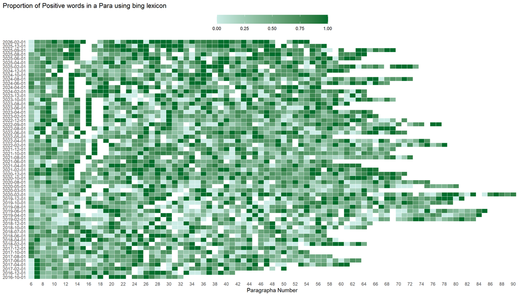

## MPC Negative Sentiments - Bing

```r
mpc_sentiments_bing |>
  ggplot(aes(para_num,as.character(mpc_date))) +
  geom_tile(aes(fill = neg),colour = "#ffffff") +
  scale_fill_gradient(low = "#fdd49e",high = "#b30000")+
  scale_x_continuous(breaks = seq(6,125,2),expand = expansion(mult = c(0,0)))+
  guides(fill = guide_colourbar(barwidth = 15))+
  labs(
    y = NULL,
    x = "Paragrapha Number",
    title = "Proportion of Negative words in a Para using bing lexicon"
  ) +
  theme_minimal()+
  theme(
    plot.title.position = "plot",
    legend.position = "top",
    legend.direction = "horizontal",
    legend.title = element_blank(),
    panel.grid.major = element_blank(),
    panel.grid.minor = element_blank()
  )
```

## MPC Negative Sentiments - Bing

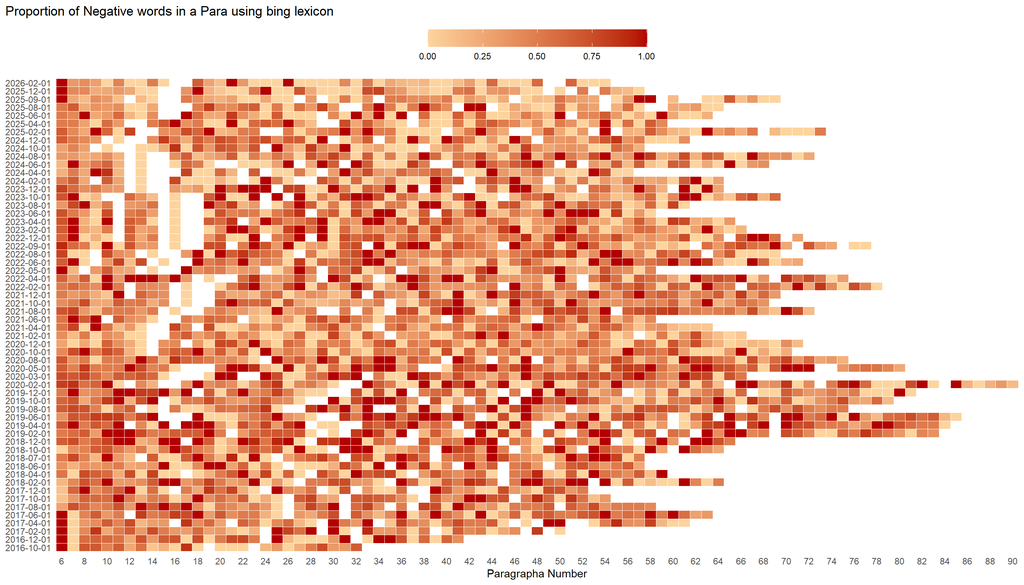

## MPC Cumulative Sentiments - Bing

```r
mpc_sentiments_bing |>
  mutate(
    cumilative = pos-neg
  ) |>
  ggplot(aes(para_num,as.character(mpc_date))) +
  geom_tile(aes(fill = cumilative),colour = "#ffffff") +
  scale_fill_gradient2(high = "#4575b4",low = "#d73027",mid = "#ffffbf")+
  scale_x_continuous(breaks = seq(6,125,2),expand = expansion(mult = c(0,0)))+
  guides(fill = guide_colourbar(barwidth = 15))+
  labs(
    y = NULL,
    x = "Paragrapha Number",
    title = "Cumulative prop of positive sentiment words in a Para using bing lexicon"
  ) +
  theme_minimal()+
  theme(
    plot.title.position = "plot",
    legend.position = "top",
    legend.direction = "horizontal",
    legend.title = element_blank(),
    panel.grid.major = element_blank(),
    panel.grid.minor = element_blank()
  )
```

## MPC Cumulative Sentiments - Bing

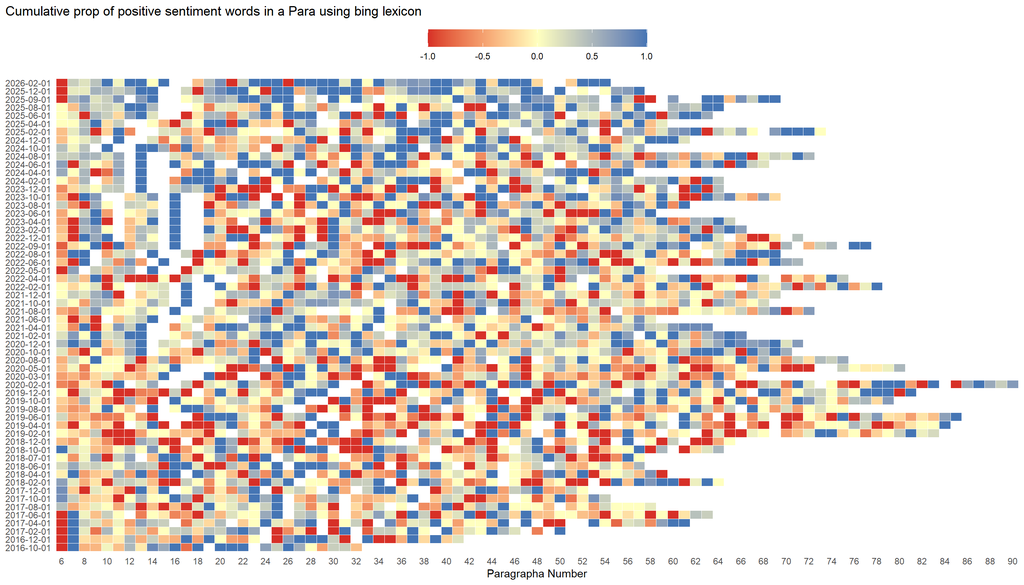

## Same stuff using Loughran-McDonald

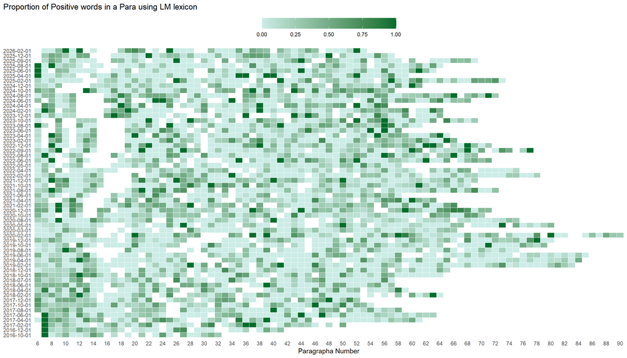

## Same stuff using Loughran-McDonald

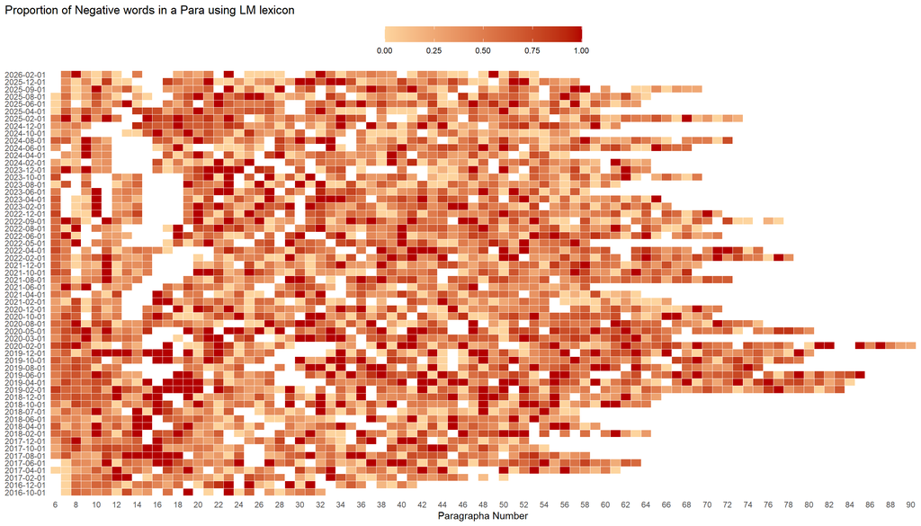

## Same stuff using Loughran-McDonald

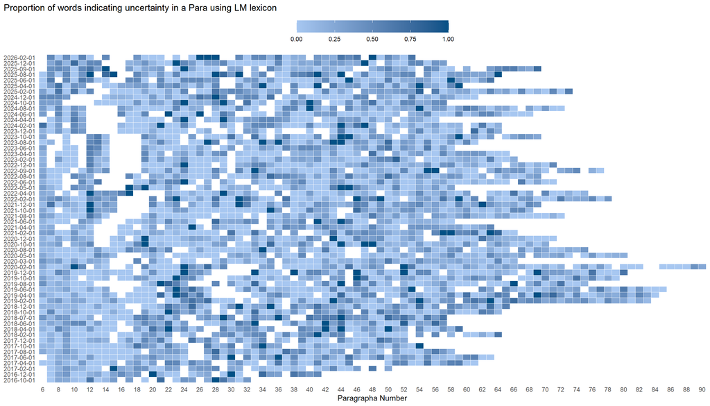

# Sentence as Token

**Using {Sentimentr}** see highlight file.

```r
mpc_minutes |>
  # Mark Para number for each line from the MPC
  filter(str_length(str_squish(lines))>2)|>
  mutate(
    lines = str_squish(lines),
    para_num = str_extract(lines,pattern = "^[:digit:]{1,2}\\. ")
  ) |>
  fill(para_num , .direction = "down") |>
  mutate(
    para_num = str_remove_all(para_num, "[:punct:]") |> str_squish() |> as.integer()
  ) |>
  # Keep only relevant para of the MPC
  filter(para_num >= 6) |>
  # Clean identifier
   mutate(
    identifier = str_remove(identifier,".{1,} Meeting|.{1,} Meeting,"),
    identifier = str_remove(identifier,"^,"),
    identifier = str_remove(identifier,"[.{1,}]"),
    identifier = lubridate::my(paste0(str_extract(str_squish(identifier),"^[:alpha:]{1,}"), str_extract(identifier," [:digit:]{4}")))
  ) |>
  group_by(identifier,para_num) |>
  summarise(
    text = str_c(lines,collapse = " ")
  ) |>
  ungroup() |>
  mutate(
    split_para = get_sentences(text)
  ) %$%
  sentiment_by(split_para, list(identifier,para_num), polartity_dt = lexicon::hash_sentiment_loughran_mcdonald) -> snetence_para_sentiment_mpc

snetence_para_sentiment_mpc
```

```
Key: <identifier, para_num>
      identifier para_num word_count         sd ave_sentiment
          <Date>    <int>      <int>      <num>         <num>
   1: 2016-10-01        6         27 0.05443311   -0.04200695
   2: 2016-10-01        7         63 0.21373734    0.22938423
   3: 2016-10-01        8         99 0.15350212   -0.06731600
   4: 2016-10-01        9        136 0.10979967   -0.05223755
   5: 2016-10-01       10        320 0.24947362    0.13992667
  ---
3517: 2026-02-01       50         46 0.02665009    0.02447871
3518: 2026-02-01       51         82 0.33281343    0.02675166
3519: 2026-02-01       52        122 0.25366620    0.31469155
3520: 2026-02-01       53        123 0.19281831   -0.14059337
3521: 2026-02-01       54        110 0.19684037    0.23015059
```

## Sentence as token

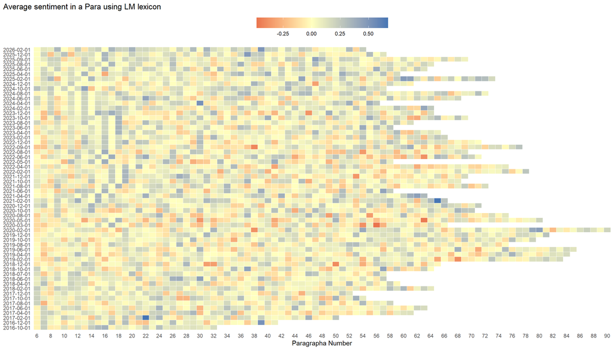

# Beyond Descriptive

> We have seen ways to perfrom some form of descriptive analysis on text data. Some of this can be extended in building features for modeling exercises.

# Topic Modeling

> We might need to divide documents in different groups to better understand what are these about.

*We use Topic Modeling, a unsupervised classification methods, to “cluseter” documents in different natural groups*

# Topic Modeling

Latent Dirichlet allocation (LDA) used for topic modeling  
Each doc is treated(modeled) as a (finite)mixture of topics  
Each tpoic is treated as a mixture of words  
Allows for overlap, complete discrete groups are not necessary

# LDA

[See paper](https://jmlr.org/papers/volume3/blei03a/blei03a.pdf) for theory/Math.

**Doc as mixture of topics**: MPC1 can be about fuel inflation due to stressed middle east conditions. This can be 10% of MPC1. MPC14 can be about food grain inflation due to poor rain. This can be 20% of MPC14…

**Topic as mixture of words**: Let us say that MPCs can be about topics like agri production, fuel price shocks, fiscal space. Each of these topics can be realted to different words. Words can overlap across topics.

# LDA

Simultaneously, LDA estimates:

1. mixture of words associated with each topic
2. mixture of topics associate with each document

# Applying LDA

A collection of speeches given by Dr Manmohan Singh is available [here](https://archive.org/details/selectedspeeches03unse).  
These are speeches delivered in year 2006-07. On various topics at various occasions/locations.  
My goal is to demonstrate how to apply LDA on these text to group them in a given number of topics.  
Lets see what comes out.

# Applying LDA

**The data**

```r
speech_data
```

```
# A tibble: 133 × 2
   title                                                                   text
   <chr>                                                                   <chr>
 1 STRIVING FOR EFFECTIVE GOVERNANCE Speech at the meeting with Chief Sec… "Str…
 2 TOWARDS ACHIEVING EXCELLENCE IN LEGAL SYSTEM Speech at Golden Jubilee … "Tow…
 3 INDIA - MARCHING STEADILY TOWARDS NEW FRONTIERS Independence Day Addre… "Ind…
 4 URGENT NEED TO DISMANTLE BARRIERS TO INTER-STATE TRADE Speech at the C… "Urg…
 5 TOWARDS UNLEASHING FULL POTENTIAL TO EXPAND NEW HORIZONS OF DEVELOPMEN… "Tow…
 6 RECOGNIZING THE NEED TO ROOT OUT CORRUPTION Keynote address to confere… "Rec…
 7 EMPOWERING PANCHAYATI RAJ FOR RURAL PROSPERITY Speech at the conferenc… "Emp…
 8 URGENT NEED FOR PARADIGM SHIFT IN DISASTER MANAGEMENT APPROACH Speech … "Urg…
 9 INCULCATING NEW VISION IN PUBLIC SERVICE Speech at the Golden Jubilee … "Inc…
10 ENSURING EQUAL PARTICIPATION OF ALL IN NATION BUILDING Address at the … "Ens…
# ℹ 123 more rows
```

# Applying LDA

**Convert data to tidytext format**

```r
speech_data|>
  unnest_tokens(word,text) -> speech_data_tidy

speech_data_tidy
```

# Applying LDA

```
# A tibble: 193,308 × 2
   title                                                                   word
   <chr>                                                                   <chr>
 1 STRIVING FOR EFFECTIVE GOVERNANCE Speech at the meeting with Chief Sec… stri…
 2 STRIVING FOR EFFECTIVE GOVERNANCE Speech at the meeting with Chief Sec… for
 3 STRIVING FOR EFFECTIVE GOVERNANCE Speech at the meeting with Chief Sec… effe…
 4 STRIVING FOR EFFECTIVE GOVERNANCE Speech at the meeting with Chief Sec… gove…
 5 STRIVING FOR EFFECTIVE GOVERNANCE Speech at the meeting with Chief Sec… i
 6 STRIVING FOR EFFECTIVE GOVERNANCE Speech at the meeting with Chief Sec… am
 7 STRIVING FOR EFFECTIVE GOVERNANCE Speech at the meeting with Chief Sec… happy
 8 STRIVING FOR EFFECTIVE GOVERNANCE Speech at the meeting with Chief Sec… to
 9 STRIVING FOR EFFECTIVE GOVERNANCE Speech at the meeting with Chief Sec… be
10 STRIVING FOR EFFECTIVE GOVERNANCE Speech at the meeting with Chief Sec… in
# ℹ 193,298 more rows
```

# Applying LDA

**get word counts by doc**

```r
speech_data_tidy |>
  anti_join(stop_words)|>
  count(title,word,sort = T) -> words_count_speech_data

words_count_speech_data
```

```
# A tibble: 51,228 × 3
   title                                                             word      n
   <chr>                                                             <chr> <int>
 1 STATEMENT ON THE INDIA-US NUCLEAR AGREEMENT Statement in Rajya S… nucl…   121
 2 STATEMENT ON THE INDIA-US NUCLEAR AGREEMENT Statement in Rajya S… india    86
 3 INTEGRATED ENERGY POLICY : TURNING ENERGY SECURITY TO REALITY Sp… ener…    49
 4 IN QUEST OF EXCELLENCE IN SCIENCE EDUCATION Speech at laying fou… scie…    46
 5 EFFECTIVE WATER MANAGEMENT : OPTIMISING THE USE Speech at the in… water    44
 6 TOWARDS EXPLORING NEW POTENTIAL OF RICE CULTIVATION Speech at th… rice     41
 7 KERALA : EXCELLENT RECORD IN HUMAN DEVELOPMENT Address at the 50… kera…    39
 8 PROMOTING SCIENCE RESEARCH AND SCIENTIFIC TEMPER ON A LARGER SCA… scie…    39
 9 RECOGNIZING THE NEED TO ROOT OUT CORRUPTION Keynote address to c… corr…    36
10 EMBARKING ON A NEW AMBITIOUS EXPANSION PLAN FOR STEEL SECTOR Spe… steel    35
# ℹ 51,218 more rows
```

# Applying LDA

**Convert tidy data to dopcument term Matrix**  
Each row is a doc, each column is a term, values are freq of appearance

```r
words_count_speech_data |>
  cast_dtm(title,word,n) -> speech_dtm

speech_dtm
```

# Applying LDA

```
<<DocumentTermMatrix (documents: 133, terms: 10079)>>
Non-/sparse entries: 51228/1289279
Sparsity           : 96%
Maximal term length: 19
Weighting          : term frequency (tf)
```

# Applying LDA

```r
speech_lda <- LDA(speech_dtm,k = 4)
```

# Infering from LDA

**How are the topics and speeches grouped?**

```r
tibble(
  title = speech_lda |> get_topics() |> names(),
  topic = speech_lda |> get_topics()
 ) |>
  arrange(topic)
```

```
# A tibble: 133 × 2
   title                                                                   topic
   <chr>                                                                   <int>
 1 INTEGRATED ENERGY POLICY : TURNING ENERGY SECURITY TO REALITY Speech a…     1
 2 IN QUEST OF EXCELLENCE IN SCIENCE EDUCATION Speech at laying foundatio…     1
 3 PROMOTING SCIENCE RESEARCH AND SCIENTIFIC TEMPER ON A LARGER SCALE Add…     1
 4 ENSURING EQUITABLE ACCESS TO ECONOMIC OPPORTUNITIES TO THE DEPRIVED SE…     1
 5 CANARA BANK : EQUIPPED TO DEAL WITH EMERGING CHALLENGES EFFECTIVELY Sp…     1
 6 FOCUS ON FINDING PRACTICAL SOLUTIONS TO THE PROBLEMS OF POWER SECTOR C…     1
 7 PERFORMANCE OF POWER SECTOR : CRUCIAL FOR THE GROWTH OF OUR ECONOMY Sp…     1
 8 PROMOTING GROWTH OF SCIENCE AND TECHNOLOGY INSTITUTIONS Speech on the …     1
 9 BLUEPRINT FOR PROSPEROUS AND EQUITABLE INDIA Address at the Meeting of…     1
10 TOWARDS TRANSFORMING POWER TO A SELF SUSTAINING SECTOR OF ECONOMY Spee…     1
# ℹ 123 more rows
```

# Infering from LDA

**Per-topic-per-word probablities**

```r
tidy(speech_lda, matric = "beta") -> speech_beta

speech_beta
```

```
# A tibble: 40,316 × 3
   topic term        beta
   <int> <chr>      <dbl>
 1     1 nuclear 0.000354
 2     2 nuclear 0.000201
 3     3 nuclear 0.00675
 4     4 nuclear 0.000280
 5     1 india   0.00584
 6     2 india   0.0129
 7     3 india   0.0179
 8     4 india   0.00590
 9     1 energy  0.00405
10     2 energy  0.00223
# ℹ 40,306 more rows
```

# Infering from LDA

**Per-topic-per-word probablities**

```r
speech_beta |>
  group_by(topic) |>
  slice_max(beta, n=10) |>
  ungroup() |>
  arrange(topic,-beta)|>
  mutate(
    term = reorder_within(term,beta,topic)
  ) |>
    ggplot(aes(beta,term)) +
    geom_col(aes(fill = factor(topic))) +
    facet_wrap(~topic, scales = "free") +
    scale_y_reordered() +
    theme_minimal() +
    theme(legend.position = "none")
```

# Infering from LDA

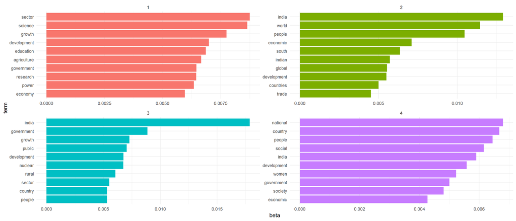

# Infering from LDA

**You can also show term probablities as distance across two topics**  
The distance between the probability of a term `k` in topic `A` and topic `B`, for all `K` terms.  
in our case this can be done for `K` terms across pairs of topics `1-2`,`1-3`,`1-4`,`2-3`,`2-4`,`3-4`  
Since some probablities are very small, best show the distance as $log_2(\frac{\beta_2}{\beta_1})$

# Inferring from LDA

**per-document-per-topic probabilities**

```r
speech_lda |>
  tidy(matrix = "gamma") |>
  arrange(document)
```

```
# A tibble: 532 × 3
   document                                                       topic    gamma
   <chr>                                                          <int>    <dbl>
 1 AGENDA FOR SOCIO-ECONOMIC TRANSFORMATION Speech at the meetin…     1 1.000e+0
 2 AGENDA FOR SOCIO-ECONOMIC TRANSFORMATION Speech at the meetin…     2 4.61 e-5
 3 AGENDA FOR SOCIO-ECONOMIC TRANSFORMATION Speech at the meetin…     3 4.61 e-5
 4 AGENDA FOR SOCIO-ECONOMIC TRANSFORMATION Speech at the meetin…     4 4.61 e-5
 5 AT THE THRESHOLD OF INCREASED ECONOMIC COOPERATION WITH AFGHA…     1 6.73 e-5
 6 AT THE THRESHOLD OF INCREASED ECONOMIC COOPERATION WITH AFGHA…     2 1.000e+0
 7 AT THE THRESHOLD OF INCREASED ECONOMIC COOPERATION WITH AFGHA…     3 6.73 e-5
 8 AT THE THRESHOLD OF INCREASED ECONOMIC COOPERATION WITH AFGHA…     4 6.73 e-5
 9 BACKWARD REGIONS GRANT FUND : TOWARDS CAPACITY BUILDING OF PA…     1 5.90 e-5
10 BACKWARD REGIONS GRANT FUND : TOWARDS CAPACITY BUILDING OF PA…     2 5.90 e-5
# ℹ 522 more rows
```

# Finding the right `k`

```r
FindTopicsNumber(
  speech_dtm,
  topics = c(2:60),
  metrics = c("Griffiths2004", "CaoJuan2009", "Arun2010", "Deveaud2014"),
  method = "Gibbs",
  mc.cores = 3L,
  verbose = TRUE) -> results_lda_speech
```

# Finding the right `k`

```
fit models... done.
calculate metrics:
  Griffiths2004... done.
  CaoJuan2009... done.
  Arun2010... done.
  Deveaud2014... done.
```

# Finding the right `k`

```r
FindTopicsNumber_plot(results_lda_speech)
```

# Finding the right `k`

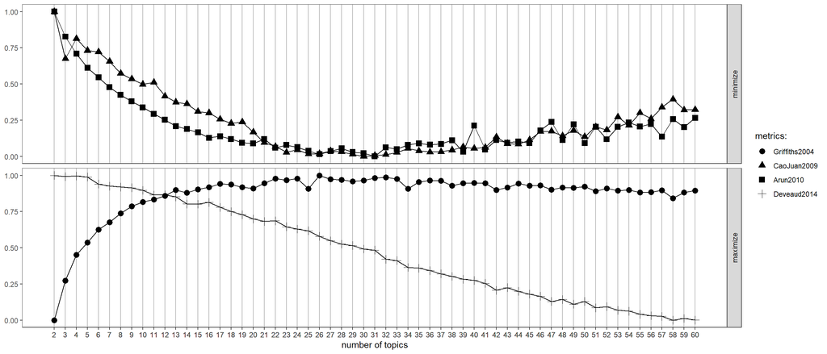

# Supervised models for text analysis

> Deep learning examples

# Dense Neural Netowrks

**Densely-connected neural network (feed-forward)**

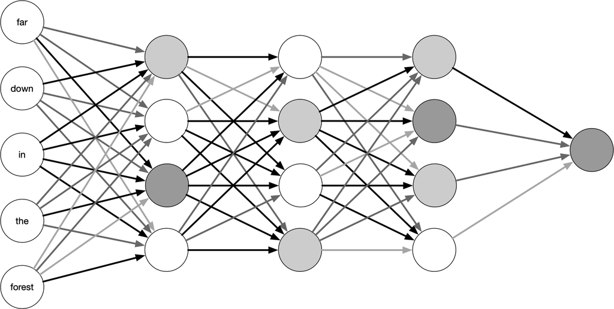

from smltar

# Dense Neural Network

Input is provided all at once  
Inputs are fully connected to the first hidden layer (densely)  
“Neurons” of a given layer are only connected to the next layer  
The number of layers and the number of neurons in a layer are variable and are hyperparameter of the model  
What is not accurate in the previous image?

# Dense Neural Network

We use data from Reuters on news description. We try to classify news based on description.

# Dense Neural Network

**Data**

```
Rows: 120,000
Columns: 2
$ class_index   <fct> 3, 3, 3, 3, 3, 3, 3, 3, 3, 3, 3, 3, 3, 3, 3, 3, 3, 3, 3,…
$ combined_text <chr> "Wall St. Bears Claw Back Into the Black (Reuters). Reut…
```

# Dense Neural Network

**Traing and Test sets**

```r
news |>
  rsample::initial_split() -> news_split

news_train <- rsample::training(news_split)

news_test <- rsample::testing(news_split)
```

# Dense Neural Network

**Pre-processing**  
Sequences are modeled. Need to choose a max length of sequence.  
Observations(docs/articles/chapters) longer than the chosen sequence are truncated  
Observations shorter than the chosen sequence are cushioned by non-informative value  
Sequence lenght is a hyperparamenter.  
Best sequence lenght is something that does not waste too much information and doesnt add too many non-informative values

# Dense Neural Networks

**Pre-processing**

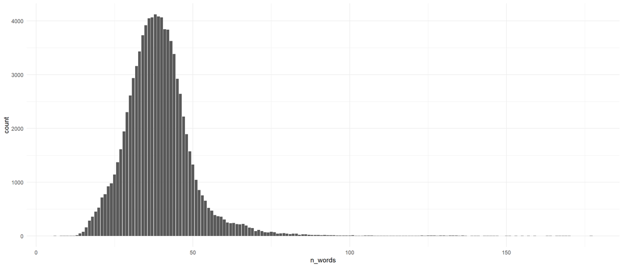

# Dense Neural Networks

**Pre-processing**

```r
max_words <- 3e4

max_length <- 80
```

# Dense Neural Networks

**Feature Engineeing**

```r
news_recipe <- recipe(
  ~ combined_text,
  data = news_train
  ) |>
    step_tokenize(combined_text) |>
    step_tokenfilter(combined_text, max_tokens = max_words) |>
    step_sequence_onehot(combined_text, sequence_length = max_length,
    truncating = "post")
```

# Dense Neural Networks

**Feature Engineeing**

1. one-hot sequence embedding transforms tokens to a numeric class so that we can perform modelling.
2. Also, one-hot sequence embedding considers the order of the tokens as well, unlike tf and tf-idf

# Dense Neural Network

**Tiny example of what features* look like**

```r
small_data <- tibble(
  text = c("Adventure Dice Game",
           "Spooky Dice Game",
           "Illustrated Book of Monsters",
           "Monsters, Ghosts, Goblins, Me, Myself and I")
)

small_spec <- recipe(~ text, data = small_data) %>%
  step_tokenize(text) %>%
  step_sequence_onehot(text, sequence_length = 6, prefix = "")

prep(small_spec)
```

# Dense Neural Network

**Tiny example of what features* look like**

```r
prep(small_spec) %>%
  tidy(2)
```

```
# A tibble: 14 × 4
   terms vocabulary token       id
   <chr>      <int> <chr>       <chr>
 1 text           1 adventure   sequence_onehot_E7Zwe
 2 text           2 and         sequence_onehot_E7Zwe
 3 text           3 book        sequence_onehot_E7Zwe
 4 text           4 dice        sequence_onehot_E7Zwe
 5 text           5 game        sequence_onehot_E7Zwe
 6 text           6 ghosts      sequence_onehot_E7Zwe
 7 text           7 goblins     sequence_onehot_E7Zwe
 8 text           8 i           sequence_onehot_E7Zwe
 9 text           9 illustrated sequence_onehot_E7Zwe
10 text          10 me          sequence_onehot_E7Zwe
11 text          11 monsters    sequence_onehot_E7Zwe
12 text          12 myself      sequence_onehot_E7Zwe
13 text          13 of          sequence_onehot_E7Zwe
14 text          14 spooky      sequence_onehot_E7Zwe
```

# Dense Neural Network

**Tiny example of what features* look like** (where are the monsters in the matrix ?)

```r
prep(small_spec) %>%
  bake(new_data = NULL, composition = "matrix")
```

```
     _text_1 _text_2 _text_3 _text_4 _text_5 _text_6
[1,]       0       0       0       1       4       5
[2,]       0       0       0      14       4       5
[3,]       0       0       9       3      13      11
[4,]       6       7      10      12       2       8
```

# Dense Neural Network

```r
news_prep <- prep(news_recipe)

news_train_prepped <- bake(news_prep,
      new_data = NULL,
      composition = "matrix")

dim(news_train_prepped)
```

```
[1] 90000    80
```

# Dense Neural Network

**A simple flattened dense network**

```r
dense_news <- keras_model_sequential(input_shape = c(80)) |> # a linear stack of layers
  layer_embedding(
    input_dim = max_words + 1,
    output_dim = 12,
    input_length = max_length
  ) |>
    layer_flatten() |>
    layer_dense(units = 32, activation = "relu") |>
    layer_dense(unit = 4, activation = "softmax")

  dense_news
```

# Dense Neural Network

```
Model: "sequential"
┌───────────────────────────────────┬──────────────────────────┬───────────────
│ Layer (type)                      │ Output Shape             │       Param #
├───────────────────────────────────┼──────────────────────────┼───────────────
│ embedding (Embedding)             │ (None, 80, 12)           │       360,012
├───────────────────────────────────┼──────────────────────────┼───────────────
│ flatten (Flatten)                 │ (None, 960)              │             0
├───────────────────────────────────┼──────────────────────────┼───────────────
│ dense (Dense)                     │ (None, 32)               │        30,752
├───────────────────────────────────┼──────────────────────────┼───────────────
│ dense_1 (Dense)                   │ (None, 4)                │           132
└───────────────────────────────────┴──────────────────────────┴───────────────
 Total params: 390,896 (1.49 MB)
 Trainable params: 390,896 (1.49 MB)
 Non-trainable params: 0 (0.00 B)
```

# Dense Neural Network

**A simple flattened dense network**

`keras_model_sequential()`: compose a stack of layers with no feedback, skips or loops, i.e. **linear stack of layers**

`layer_embedding()`: Data is converted to a tensor of $n_{obs} * S_{max} * OutDim$, in our case (90,000 * 80* 12)

`layer_flatten()`: the 12 * 80 matrix is converted into a vector with 960 features. So each news description is 960 numbers.

# Dense Neural Network

**Optimization alogrithm and loss function**

```r
dense_news |>
  compile(
    optimizer = optimizer_adam(), #"adam"
    loss = loss_sparse_categorical_crossentropy(), #"sparse_categorical_crossentropy"
    metrics = metric_sparse_categorical_accuracy() #c("accuracy")
  )
```

# Dense Neural Network

**Fitting the model**

```r
dense_fit_news <- dense_news |>
  fit(
    x = news_train_prepped,
    y = as.integer(news_train$class_index)-1, # carefull
    batch_size = 250,
    epochs = 20,
    validation_split = 0.25
  )
```

```
270/270 - 1s - 5ms/step - loss: 0.6767 - sparse_categorical_accuracy: 0.7400 - val_loss: 0.2859 - val_sparse_categorical_accuracy: 0.9048
270/270 - 1s - 3ms/step - loss: 0.2208 - sparse_categorical_accuracy: 0.9268 - val_loss: 0.2485 - val_sparse_categorical_accuracy: 0.9168
270/270 - 1s - 3ms/step - loss: 0.1489 - sparse_categorical_accuracy: 0.9512 - val_loss: 0.2521 - val_sparse_categorical_accuracy: 0.9148
270/270 - 1s - 3ms/step - loss: 0.1000 - sparse_categorical_accuracy: 0.9693 - val_loss: 0.2796 - val_sparse_categorical_accuracy: 0.9110
270/270 - 1s - 3ms/step - loss: 0.0621 - sparse_categorical_accuracy: 0.9827 - val_loss: 0.3001 - val_sparse_categorical_accuracy: 0.9120
270/270 - 1s - 5ms/step - loss: 0.0354 - sparse_categorical_accuracy: 0.9912 - val_loss: 0.3404 - val_sparse_categorical_accuracy: 0.9093
270/270 - 1s - 3ms/step - loss: 0.0198 - sparse_categorical_accuracy: 0.9954 - val_loss: 0.3737 - val_sparse_categorical_accuracy: 0.9066
270/270 - 1s - 3ms/step - loss: 0.0130 - sparse_categorical_accuracy: 0.9969 - val_loss: 0.4050 - val_sparse_categorical_accuracy: 0.9054
270/270 - 1s - 3ms/step - loss: 0.0089 - sparse_categorical_accuracy: 0.9979 - val_loss: 0.4291 - val_sparse_categorical_accuracy: 0.9058
270/270 - 1s - 4ms/step - loss: 0.0066 - sparse_categorical_accuracy: 0.9984 - val_loss: 0.4487 - val_sparse_categorical_accuracy: 0.9051
270/270 - 1s - 3ms/step - loss: 0.0061 - sparse_categorical_accuracy: 0.9985 - val_loss: 0.4616 - val_sparse_categorical_accuracy: 0.9041
270/270 - 1s - 3ms/step - loss: 0.0046 - sparse_categorical_accuracy: 0.9989 - val_loss: 0.4888 - val_sparse_categorical_accuracy: 0.9049
270/270 - 1s - 3ms/step - loss: 0.0041 - sparse_categorical_accuracy: 0.9990 - val_loss: 0.5125 - val_sparse_categorical_accuracy: 0.9043
270/270 - 1s - 4ms/step - loss: 0.0036 - sparse_categorical_accuracy: 0.9990 - val_loss: 0.5236 - val_sparse_categorical_accuracy: 0.9030
270/270 - 1s - 4ms/step - loss: 0.0031 - sparse_categorical_accuracy: 0.9992 - val_loss: 0.5365 - val_sparse_categorical_accuracy: 0.9030
270/270 - 1s - 4ms/step - loss: 0.0030 - sparse_categorical_accuracy: 0.9992 - val_loss: 0.5538 - val_sparse_categorical_accuracy: 0.9019
270/270 - 1s - 4ms/step - loss: 0.0030 - sparse_categorical_accuracy: 0.9992 - val_loss: 0.6205 - val_sparse_categorical_accuracy: 0.8979
270/270 - 1s - 4ms/step - loss: 0.0031 - sparse_categorical_accuracy: 0.9992 - val_loss: 0.5694 - val_sparse_categorical_accuracy: 0.9011
270/270 - 1s - 4ms/step - loss: 0.0026 - sparse_categorical_accuracy: 0.9993 - val_loss: 0.5904 - val_sparse_categorical_accuracy: 0.9007
270/270 - 1s - 4ms/step - loss: 0.0018 - sparse_categorical_accuracy: 0.9996 - val_loss: 0.5987 - val_sparse_categorical_accuracy: 0.9012
```

```r
dense_fit_news
```

```
Final epoch (plot to see history):
                           loss: 0.001826
    sparse_categorical_accuracy: 0.9996
                       val_loss: 0.5987
val_sparse_categorical_accuracy: 0.9012
```

# Dense Neural Network

```r
plot(dense_fit_news) +
  theme_minimal()
```

# Dense Neural Network

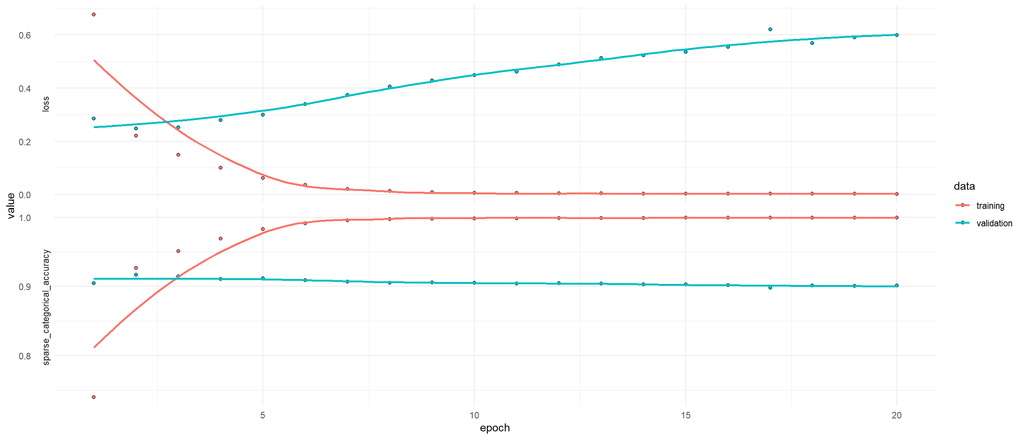

# Dense Neural Network

**Evaluate on test**

```r
news_baked <- bake(news_prep, new_data = news_test, composition = "matrix")

dim(news_baked)
```

```
[1] 30000    80
```

# Dense Neural Network

```r
news_baked_response <- as.integer(news_test$class_index)-1

dense_fit_test <- dense_news |>
  fit(
    x = news_train_prepped,
    y = as.integer(news_train$class_index)-1, # carefull
    batch_size = 250,
    epochs = 3,
    validation_data = list(news_baked, news_baked_response)
  )
```

```
360/360 - 1s - 4ms/step - loss: 0.1086 - sparse_categorical_accuracy: 0.9722 - val_loss: 0.3309 - val_sparse_categorical_accuracy: 0.9033
360/360 - 1s - 3ms/step - loss: 0.0291 - sparse_categorical_accuracy: 0.9924 - val_loss: 0.4459 - val_sparse_categorical_accuracy: 0.8990
360/360 - 1s - 3ms/step - loss: 0.0098 - sparse_categorical_accuracy: 0.9978 - val_loss: 0.5097 - val_sparse_categorical_accuracy: 0.8975
```

```r
dense_fit_test
```

```
Final epoch (plot to see history):
                           loss: 0.009771
    sparse_categorical_accuracy: 0.9978
                       val_loss: 0.5097
val_sparse_categorical_accuracy: 0.8975
```

# Dense Neural Network

```r
plot(dense_fit_test) +
  theme_minimal()
```

# Dense Neural Network

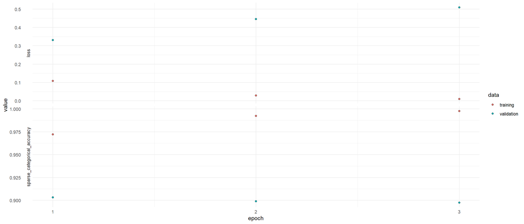

# Dense Neural Network

```r
dense_news |>
  evaluate(news_baked, news_baked_response)
```

```
938/938 - 1s - 907us/step - loss: 0.5097 - sparse_categorical_accuracy: 0.8975
```

```
$loss
[1] 0.509653

$sparse_categorical_accuracy
[1] 0.8974667
```

# Dense Neural Network

```r
dense_news |>
  predict(news_baked)
```

```
938/938 - 1s - 678us/step
```

```
                 [,1]         [,2]         [,3]         [,4]
    [1,] 2.092844e-05 9.830788e-07 2.209612e-02 9.778820e-01
    [2,] 6.820588e-05 5.416569e-07 9.999254e-01 5.869203e-06
    [3,] 8.850472e-06 2.166265e-09 9.999911e-01 1.101618e-07
    [4,] 2.589705e-05 1.530331e-08 9.999741e-01 1.964474e-09
    [5,] 4.365947e-06 8.022069e-08 9.999955e-01 8.850623e-08
    [6,] 2.955020e-08 8.627967e-10 9.999999e-01 8.865090e-08
    [7,] 9.851475e-01 3.654067e-07 1.248095e-02 2.371144e-03
    [8,] 7.628147e-02 3.326405e-06 1.315234e-02 9.105628e-01
    [9,] 2.909523e-03 3.843081e-06 9.962565e-01 8.300786e-04
   [10,] 2.461071e-05 4.851034e-07 1.016049e-01 8.983699e-01
   [11,] 3.528783e-03 2.191695e-01 7.772402e-01 6.154994e-05
   [12,] 2.518635e-03 6.234992e-04 8.308645e-01 1.659933e-01
   [13,] 4.692692e-04 1.623996e-10 9.986613e-01 8.693680e-04
   [14,] 9.566027e-05 8.827445e-08 8.558697e-05 9.998186e-01
```

[output cut: 24986 more lines]